# Intro to Data Analysis with R: Session 4

UCI Data Science Initiative

April 20, 2018

## Session 4 Agenda

- [Motivating example](https://www.youtube.com/watch?v=j4JOjcDFtBE)
- Brief Intro to Generalized Linear Models (GLMs)
- Logistic Regression
  - Fitting Models for Binary Response Data
  - Interpretation
  - Diagnostics
  - Prediction

## O-Ring Data

- On January 28, 1986, the USA Space Shuttle Challenger exploded 73 seconds into flight, killing all 7 crew members. The explosion was traced to failure of O-ring seals in the solid rocket booster at liftoff.
- It was hypothesized that there is a inverse relationship between O-ring failure and temperature.
- The night before the flight, engineers had to make a decision whether or not to lauch Challenger the next day with a forecasted temperature of 31 degrees Fahrenheit.
- The engineers had data available on 23 previous launches to aid in their decision with the following varaibles
  - Number of O-rings at risk on a given flight
  - Number experiencing thermal distress
  - Launch temperature (degrees F)
  - Leak-check pressure (psi)
  - Temporal order of flight

## O-Ring Data, contd.

More information about the O-ring data is available [here](https://archive.ics.uci.edu/ml/datasets/Challenger+USA+Space+Shuttle+O-Ring).

```r
oring <- read.table("https://archive.ics.uci.edu/ml/machine-learning-databases/space-shuttle/o-ring-erosion-only.data")
names(oring) <- c("n_risk", "n_fail", "temp", "psi", "order")
head(oring)
```

```
##   n_risk n_fail temp psi order
## 1      6      0   66  50     1
## 2      6      1   70  50     2
## 3      6      0   69  50     3
## 4      6      0   68  50     4
## 5      6      0   67  50     5
## 6      6      0   72  50     6
```

```r
summary(oring)
```

```
##      n_risk      n_fail            temp            psi
##  Min.   :6   Min.   :0.0000   Min.   :53.00   Min.   : 50.0
##  1st Qu.:6   1st Qu.:0.0000   1st Qu.:67.00   1st Qu.: 75.0
##  Median :6   Median :0.0000   Median :70.00   Median :200.0
##  Mean   :6   Mean   :0.3043   Mean   :69.57   Mean   :152.2
##  3rd Qu.:6   3rd Qu.:0.5000   3rd Qu.:75.00   3rd Qu.:200.0
##  Max.   :6   Max.   :2.0000   Max.   :81.00   Max.   :200.0
##      order
##  Min.   : 1.0
##  1st Qu.: 6.5
##  Median :12.0
##  Mean   :12.0
##  3rd Qu.:17.5
##  Max.   :23.0
```

## Visualizing the O-Ring Data

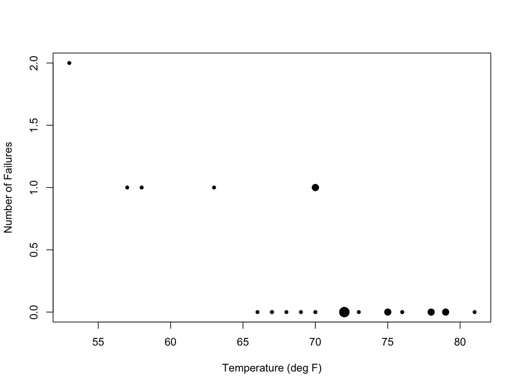

```r
oring <- oring[order(oring$temp), ]  # sort by ascending temp
# some flights have the same number of failures & launch temp, so make point size vary
pt.size <- rep(1, nrow(oring))
dups <- oring[duplicated(cbind(oring$temp, oring$n_fail)), c("n_fail", "temp")]
pt.size[as.numeric(rownames(dups))] <- 2
trips <- dups[duplicated(dups), ]
pt.size[as.numeric(rownames(trips))] <- 3
plot(oring$temp, oring$n_fail, pch = 20, cex = pt.size,
     xlab = "Temperature (deg F)", ylab = "Number of Failures")
```

## Naive Analysis of the O-Ring Data

```r
## Fit a linear model
linearReg <- lm(n_fail ~ temp, data = oring)
summary(linearReg)
```

```
##
## Call:
## lm(formula = n_fail ~ temp, data = oring)
##
## Residuals:
##      Min       1Q   Median       3Q      Max
## -0.50921 -0.30810  0.00794  0.20905  0.74381
##
## Coefficients:
##             Estimate Std. Error t value Pr(>|t|)
## (Intercept)  4.30159    0.83110   5.176 3.96e-05 ***
## temp        -0.05746    0.01189  -4.833 8.90e-05 ***
## ---
## Signif. codes:  0 '***' 0.001 '**' 0.01 '*' 0.05 '.' 0.1 ' ' 1
##
## Residual standard error: 0.3935 on 21 degrees of freedom
## Multiple R-squared:  0.5266, Adjusted R-squared:  0.5041
## F-statistic: 23.36 on 1 and 21 DF,  p-value: 8.895e-05
```

## Naive Analysis Results

```r
## Predict the output for the Challenger launch day
launchDay <- data.frame(temp = 31)
predict(linearReg, launchDay, interval="predict")  # point estimate & 95% CI
```

```
##        fit      lwr     upr
## 1 2.520317 1.252255 3.78838
```

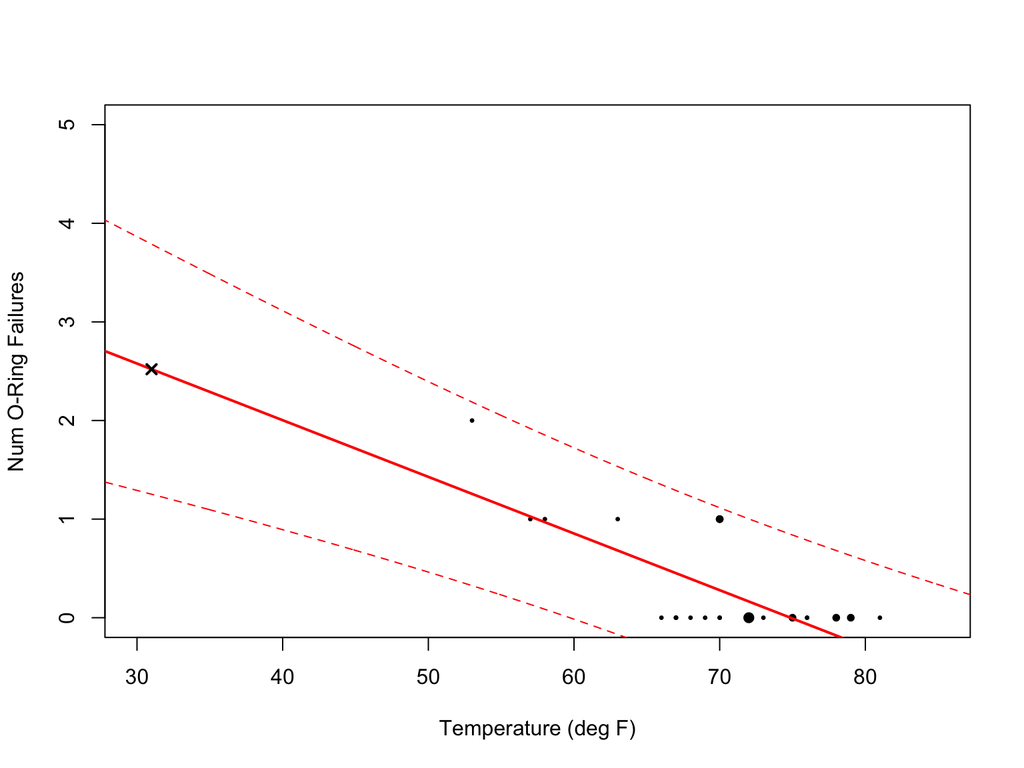

```r
## Plot the fit extrapolating to launch day
plot(oring$temp, oring$n_fail, pch = 20, cex = pt.size/2,
     xlab = "Temperature (deg F)", ylab = "Num O-Ring Failures",
     xlim = c(30, 85), ylim = c(0, 5))
abline(reg = linearReg, col = "red", lwd = 2)
points(x=31, y=2.52, pch=4, col="black", lwd=2)
x <- seq(25,90,.1)
pred <- predict(linearReg, data.frame(temp=x), interval="predict")
lines(x, pred[,2], lty=2, col="red")
lines(x, pred[,3], lty=2, col="red")
```

## Generalized Linear Models (GLMs)

- Linear regression clearly isn’t the proper technique for this type of data, but GLMs can overcome these issues.
- Flexible extension of linear regression that allows response variable to have non-Gaussian error distributions.
- Instead of modeling the mean $\mu$ of the response variable directly as a linear combination of the predictors, we model a **link function** $g(\mu)$.
  $$g[E(Y)] = X \beta \Rightarrow E(Y) = g^{-1}(X \beta)$$
- $Y$ must have a distribution from the *exponential family*, which includes the Normal, binomial, Poisson, gamma, and many others.
- Choice of link function $g$ depends on the distributional form of $Y$. There can be multiple link functions for any singe distribution.

## Logistic Regression

- Specific GLM when dealing with binary response data $Y_i \in \{0,1\}$
  $$Y_i \sim Bernoulli(p_i)$$
  $$\Rightarrow f(Y|p) = \prod_{i=1}^{n} \left[ p_i^{y_i} (1-p_i)^{1-y_i} \right]$$
  where $p_i \in [0,1]$ is the probability that $Y_i = 1$.
- Link function must map values in $(-\infty, \infty)$ to the range $[0,1]$
  - **logit**, probit (normal CDF), etc
- Logit link function: $g(p) = \log\left( \frac{p}{1-p} \right) = X\beta$
- Inverse of logit function is the logistic function: $p = g^{-1}(X\beta) = \frac{e^{X\beta}}{e^{X\beta} + 1} = \frac{1}{1+e^{-X\beta}}$

## GLMs in R

- `glm()` is used to fit generalized linear models.
- The `formula` argument is equivalent to that of `lm()` used for linear regression
- New argument: `family`
  - Specifies the distribution of the response varaible and the link function
  - Logistic regression: `family = binomial(link="logit")`
- `Summary()`, `update()`, `predict()`, variable selection methods, etc. all work the same

## Logistic Regression - Format Data

```r
## Reformat the response variable
oring$fail <- as.numeric(oring$n_fail > 0)
head(oring)
```

```
##    n_risk n_fail temp psi order fail
## 14      6      2   53 200    14    1
## 9       6      1   57 200     9    1
## 23      6      1   58 200    23    1
## 10      6      1   63 200    10    1
## 1       6      0   66  50     1    0
## 5       6      0   67  50     5    0
```

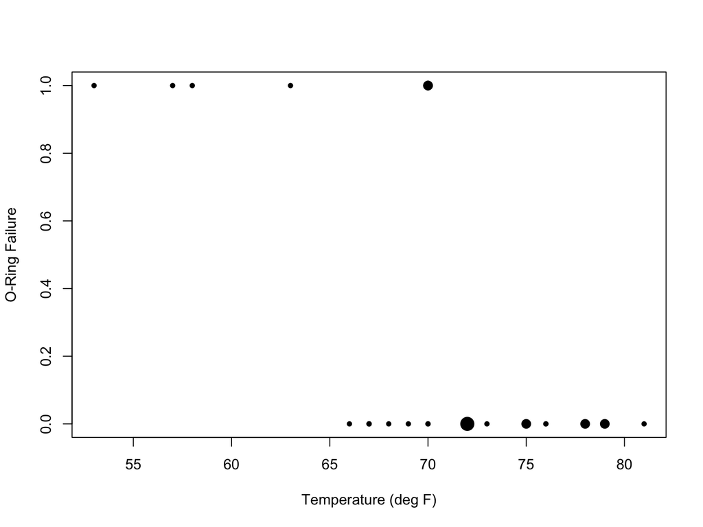

```r
plot(oring$temp, oring$fail, pch = 20, cex = pt.size,
     xlab = "Temperature (deg F)", ylab = "O-Ring Failure")
```

## Logistic Regression - Fit the Model

```r
## Fit a GLM with logistic link
logisticReg <- glm(fail ~ temp, data = oring, family=binomial(link="logit"))
summary(logisticReg)
```

```
##
## Call:
## glm(formula = fail ~ temp, family = binomial(link = "logit"),
##     data = oring)
##
## Deviance Residuals:
##      Min        1Q    Median        3Q       Max
## -1.00214  -0.57815  -0.21802   0.04401   2.01706
##
## Coefficients:
##             Estimate Std. Error z value Pr(>|z|)
## (Intercept)  23.7750    11.8204   2.011   0.0443 *
## temp         -0.3667     0.1752  -2.093   0.0363 *
## ---
## Signif. codes:  0 '***' 0.001 '**' 0.01 '*' 0.05 '.' 0.1 ' ' 1
##
## (Dispersion parameter for binomial family taken to be 1)
##
##     Null deviance: 26.402  on 22  degrees of freedom
## Residual deviance: 14.426  on 21  degrees of freedom
## AIC: 18.426
##
## Number of Fisher Scoring iterations: 6
```

## Logistic Regression

```r
names(logisticReg)
```

```
##  [1] "coefficients"      "residuals"         "fitted.values"
##  [4] "effects"           "R"                 "rank"
##  [7] "qr"                "family"            "linear.predictors"
## [10] "deviance"          "aic"               "null.deviance"
## [13] "iter"              "weights"           "prior.weights"
## [16] "df.residual"       "df.null"           "y"
## [19] "converged"         "boundary"          "model"
## [22] "call"              "formula"           "terms"
## [25] "data"              "offset"            "control"
## [28] "method"            "contrasts"         "xlevels"
```

## Logistic Regression - Plot the Fit

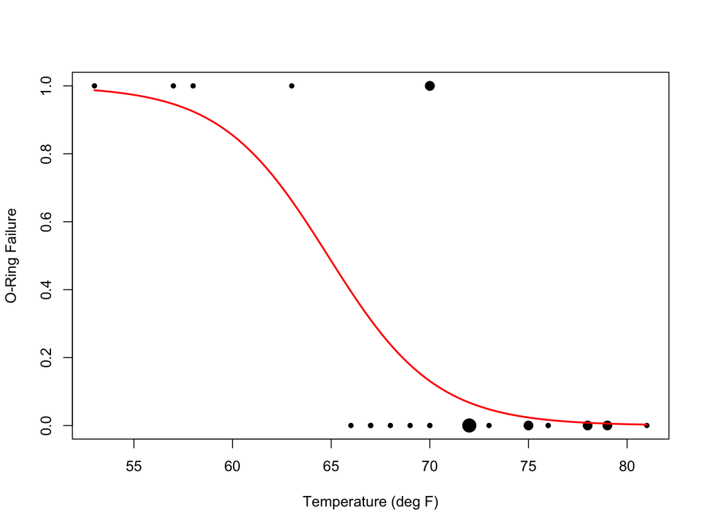

```r
plot(oring$temp, oring$fail, pch = 20, cex = pt.size,
     xlab = "Temperature (deg F)", ylab = "O-Ring Failure")
curve(predict(logisticReg, data.frame(temp=x), type="response"), add=TRUE, col="red", lwd=2)
```

## Logistic Regression - Prediction

To get probabilities, be sure to use `type = "response"`.

```r
launchDay
```

```
##   temp
## 1   31
```

```r
predict(logisticReg, launchDay, type="response")
```

```
##         1
## 0.9999959
```

`predict()` simply computes the linear combination & evaulates the inverse link

```r
XB <- as.numeric(coef(logisticReg)[1] + coef(logisticReg)[2]*31)
XB  # estimated log-odds of o-ring failure on launch day
```

```
## [1] 12.40723
```

```r
exp(XB)/(1 + exp(XB))  # estimated probability of o-ring failure on launch day
```

```
## [1] 0.9999959
```

## Logistic Regression - Exponentiated CIs

- $\exp(\beta)$ is the multiplicative change in the odds of O-ring failure for a one degree increase in temperature.
- 95% CI for $\exp(\beta)$ (profile likelihood method)

```r
exp(confint(logisticReg, "temp", level=0.95))
```

```
##     2.5 %    97.5 %
## 0.4159216 0.8853986
```

- 95% CI for $\exp(\beta)$ (Wald confidence interval)

```r
exp(confint.default(logisticReg, "temp", level=0.95))
```

```
##          2.5 %    97.5 %
## temp 0.4916331 0.9768919
```

## Logistic Regression - Updates

- Update model by adding leak check pressure

```r
logisticReg2 = update(logisticReg, . ~ . + psi, data=oring)
summary(logisticReg2)
```

```
##
## Call:
## glm(formula = fail ~ temp + psi, family = binomial(link = "logit"),
##     data = oring)
##
## Deviance Residuals:
##      Min        1Q    Median        3Q       Max
## -1.00837  -0.54507  -0.28098   0.02512   2.21488
##
## Coefficients:
##              Estimate Std. Error z value Pr(>|z|)
## (Intercept) 21.843631  11.936459   1.830   0.0673 .
## temp        -0.350098   0.172977  -2.024   0.0430 *
## psi          0.006007   0.009749   0.616   0.5378
## ---
## Signif. codes:  0 '***' 0.001 '**' 0.01 '*' 0.05 '.' 0.1 ' ' 1
##
## (Dispersion parameter for binomial family taken to be 1)
##
##     Null deviance: 26.402  on 22  degrees of freedom
## Residual deviance: 14.033  on 20  degrees of freedom
## AIC: 20.033
##
## Number of Fisher Scoring iterations: 6
```

## Logistic Regression - Model Comparison

- Likelihood Ratio Test instead of F-test like in Linear Regression

```r
anova(logisticReg, logisticReg2, test='LRT')
```

```
## Analysis of Deviance Table
##
## Model 1: fail ~ temp
## Model 2: fail ~ temp + psi
##   Resid. Df Resid. Dev Df Deviance Pr(>Chi)
## 1        21     14.426
## 2        20     14.033  1   0.3929   0.5308
```

## End of Session 4

**Make sure you submit a [course evaluation survey](https://docs.google.com/forms/d/e/1FAIpQLSdGC3RVoEzulw9STMBAWvXTahUetxc-PrGhNRW5AmtQ1ZMwMw/viewform)!**